# language_detection

```r
library(tidyverse)
```

## Introduction

In this document, we evaluate the various type of models we propose for language detection purpose

## Dataset

For the purpose of this analysis, we use Airbnb internal translated (by translation team) phrases for employees generated contents. This include

- Website contents
- Email contents

We have roughly 12M total phrases with corresponding language (label), we split it:

- valid (10K)
- eval (10K)
- training (remainder)

```r
eval_data <- read.csv(
  "data/eval_data.csv",
  sep="\t",
  blank.lines.skip=TRUE,
  stringsAsFactors=FALSE
)
eval_data <- eval_data %>%
  mutate(
    langid_prob = as.numeric(langid_prob),
    langdetect_prob = as.numeric(langdetect_prob)
  )

valid_data <- read.csv(
  "data/valid_data.csv",
  sep="\t",
  blank.lines.skip=TRUE,
  stringsAsFactors=FALSE
)
valid_data <- valid_data %>%
  mutate(
    langid_prob = as.numeric(langid_prob),
    langdetect_prob = as.numeric(langdetect_prob)
  )
```

## Baseline

We evaluate Google language detection API on phrases on eval and present result in this section.

Google phrase locales sample:

```r
head(eval_data)
```

|  | X | Unnamed..0 | Unnamed..0.1 | Unnamed..0.1.1 | value | locale | text_cat_locale | langid_locale | google_translate_locale | curated_value | langid_prob | langdetect_locale | langdetect_prob | size |
| --- | --- | --- | --- | --- | --- | --- | --- | --- | --- | --- | --- | --- | --- | --- |
| 1 | 0 | 0 | 0 | 7899889 | Puy-de-Dôme'de kiralık yer mi arıyorsunuz? | tr | tur | tr | tr | Puy-de-Dôme'de kiralık yer mi arıyorsunuz? | 0.9999999 | tr | 0.9999987 | 5 |
| 2 | 3 | 3 | 3 | 1302482 | Du yoga sur la plage | fr | cor | fr | fr | Du yoga sur la plage | 0.9713175 | fr | 0.4285715 | 5 |
| 3 | 4 | 4 | 4 | 5863204 | \tOvěření Ti napomáhají budovat si důvěru v naší komunitě, protože ukazují, že jsi provedl/a kroky navíc k tomu, abys dokázal/a, že&nbsp; jsi opravdu tak skvělý člověk, za kterého se vydáváš. Objeví s… | cs | ces | af | cs | \tOvěření Ti napomáhají budovat si důvěru v naší komunitě, protože ukazují, že jsi provedl/a kroky navíc k tomu, abys dokázal/a, že&nbsp; jsi opravdu tak skvělý člověk, za kterého se vydáváš. Objeví s… | NA | cs | 0.9999958 | 205 |
| 4 | 6 | 6 | 6 | 8018854 | Yemyeşil ve popüler Barton Hills'in harika dış mekanları ve keyifli gece hayatı. | tr | tur | tr | tr | Yemyeşil ve popüler Barton Hills'in harika dış mekanları ve keyifli gece hayatı. | 0.9999998 | tr | 0.9999990 | 12 |
| 5 | 7 | 7 | 7 | 9641428 | Esta atividade foi adicionada ao seu itinerário. | pt | glg | pt | pt | Esta atividade foi adicionada ao seu itinerário. | 0.9999082 | pt | 0.9999951 | 7 |
| 6 | 9 | 9 | 9 | 580613 | \t發送預准即表示您給予房客24小時的時間確認預訂，您不需要進一步採取任何行動。 \t您應在準備好確認預訂時才發送預准。如果房客在24小時內預訂了您的房源，該預訂就會自動確認。 \t預准房客： \t%{abb:platform.desktop, moweb[0]} %{abb:platform.ios, android[0]} \t關於預准，以下有幾點您需要注意： \t \t\t預准房客後，您房源… | zh | eng | af | zh | \t發送預准即表示您給予房客24小時的時間確認預訂，您不需要進一步採取任何行動。 \t您應在準備好確認預訂時才發送預准。如果房客在24小時內預訂了您的房源，該預訂就會自動確認。 \t預准房客： \t \t關於預准，以下有幾點您需要注意： \t \t\t預准房客後，您房源日曆上的對應日期仍會標記為可供出租。 \t \t\t您可在同一日期預准多位房客。如果房源被預訂了，其他房客會自動收到通知。 \t … | NA | ko | 0.7142840 | 18 |

Overall precision of google api:

```r
eval_data %>%
  summarise(precision=sum(ifelse(locale == google_translate_locale, 1, 0)) / n())
```

| precision |
| --- |
| 0.8441164 |

What is the breakdown by each language category?

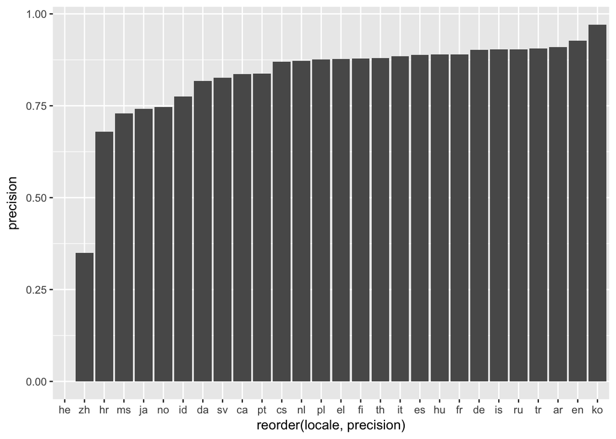

```r
eval_data %>%
  group_by(locale) %>%
  summarise(precision = sum(ifelse(locale == google_translate_locale, 1, 0)) / n()) %>%
  ggplot(aes(x = reorder(locale, precision), y = precision)) +
    geom_bar(stat="identity")
```

#### Langid based model

What is the accuracy of langid & langdetect model?

```r
valid_data %>%
  summarise(
    langid_precision = sum(ifelse(locale == langid_locale, 1, 0)) / n(),
    langdetect_precision = sum(ifelse(locale == langdetect_locale, 1, 0)) / n()
  )
```

| langid_precision | langdetect_precision |
| --- | --- |
| 0.6306818 | 0.7416193 |

Langid breakdown by locale

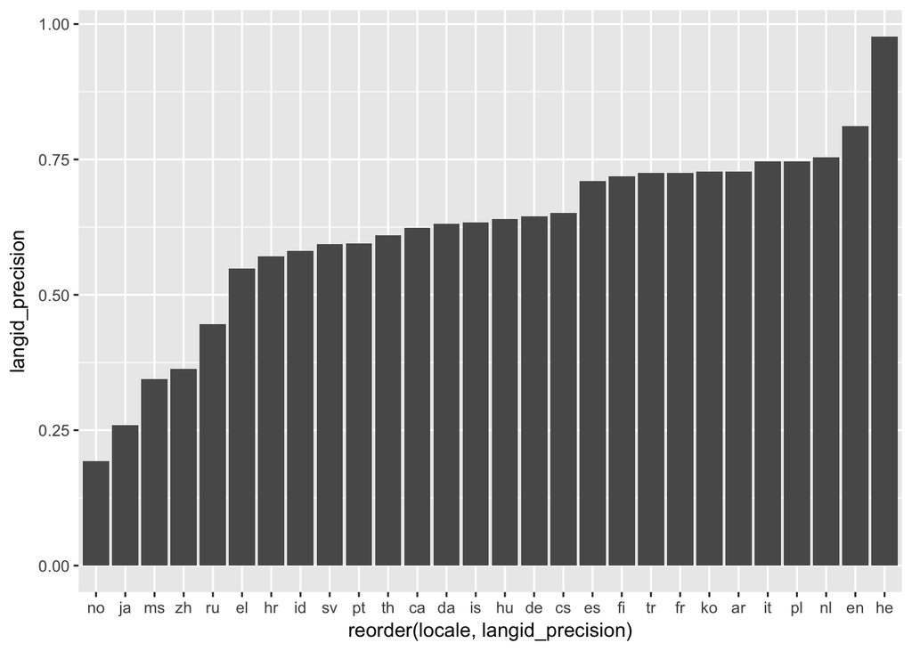

```r
valid_data %>%
  group_by(locale) %>%
  summarise(
    langid_precision = sum(ifelse(locale == langid_locale, 1, 0)) / n()
  )  %>%
  ggplot(aes(x = reorder(locale, langid_precision), y = langid_precision)) +
    geom_bar(stat="identity")
```

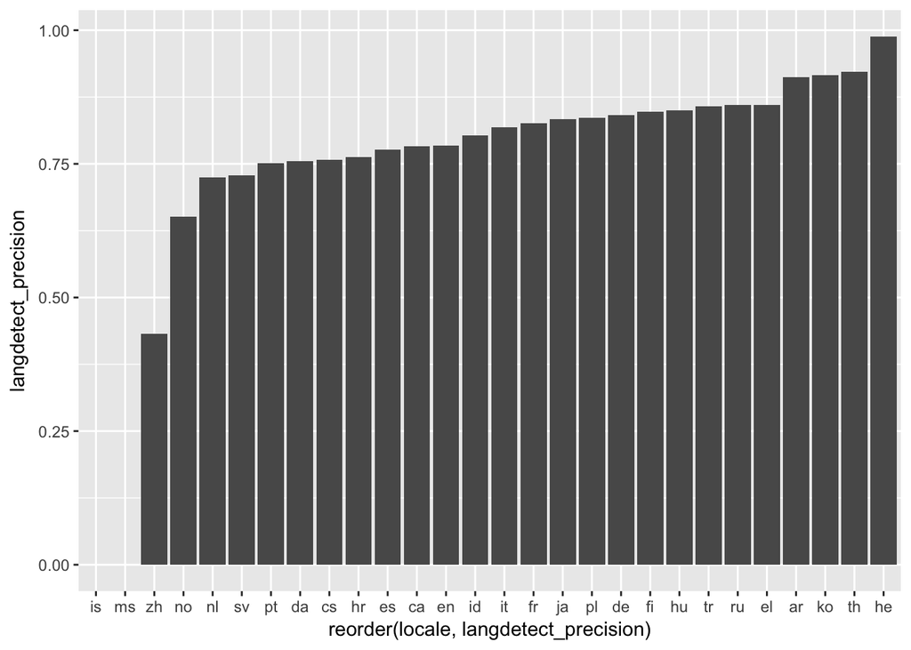

```r
valid_data %>%
  group_by(locale) %>%
  summarise(
    langdetect_precision = sum(ifelse(locale == langdetect_locale, 1, 0)) / n()
  )  %>%
  ggplot(aes(x = reorder(locale, langdetect_precision), y = langdetect_precision)) +
    geom_bar(stat="identity")
```

#### Approach-1: langid with threshold, then fall to langdetect

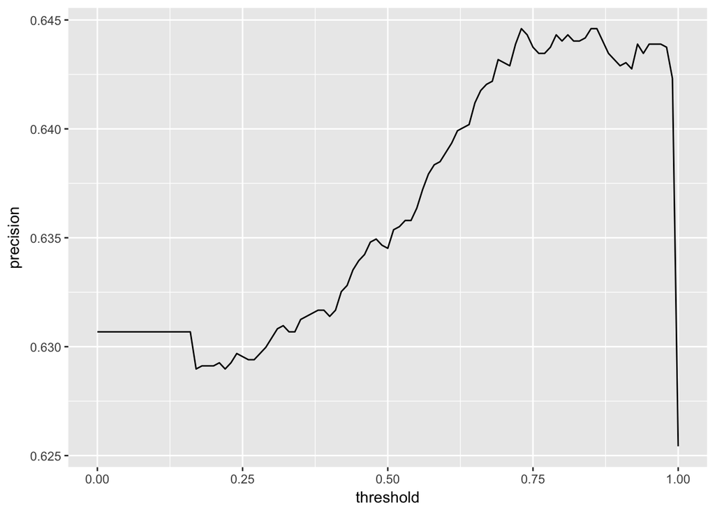

```r
langid_langdetect <- data.frame(threshold = numeric(), precision=numeric())
for (th in seq(0, 1, by=0.01)) {
  p <- (
    valid_data %>%
      mutate(mix_locale = ifelse(langid_prob >= th, langid_locale, langdetect_locale)) %>%
      summarise(precision = sum(ifelse(!is.na(mix_locale) & mix_locale == locale, 1, 0)) / n())
  )$precision

  langid_langdetect[nrow(langid_langdetect) + 1,] = c(th, p)
}

langid_langdetect %>%
  ggplot(aes(x = threshold, y = precision)) +
    geom_line()
```

```r
max_precision <- (langid_langdetect %>% summarise(max_precision = max(precision)))$max_precision
langid_threshold <- head(langid_langdetect %>% filter(precision == max_precision), 1)$threshold
```

Evaluation of chosen method is:

```r
eval_data %>%
  mutate(mix_locale = ifelse(langid_prob >= langid_threshold, langid_locale, langdetect_locale)) %>%
  summarise(precision = sum(ifelse(!is.na(mix_locale) & mix_locale == locale, 1, 0)) / n())
```

| precision |
| --- |
| 0.638019 |

#### Approach-2: langdetect with threshold, then fall to langid

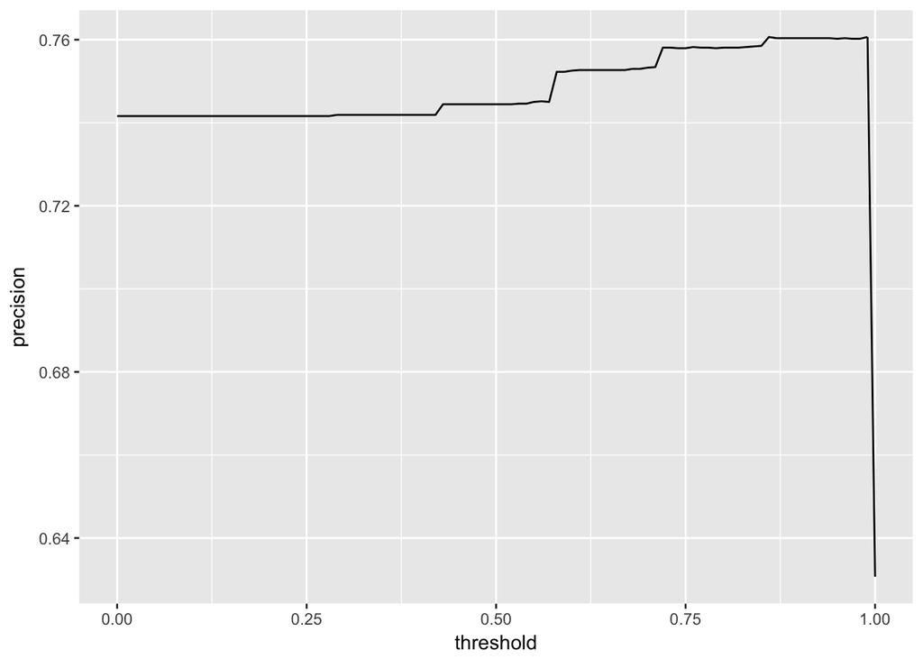

```r
langdetect_langid <- data.frame(threshold = numeric(), precision=numeric())
for (th in seq(0, 1, by=0.01)) {
  p <- (
    valid_data %>%
      mutate(mix_locale = ifelse(langdetect_prob >= th, langdetect_locale, langid_locale)) %>%
      summarise(precision = sum(ifelse(!is.na(mix_locale) & mix_locale == locale, 1, 0)) / n())
  )$precision

  langdetect_langid[nrow(langdetect_langid) + 1,] = c(th, p)
}

langdetect_langid %>%
  ggplot(aes(x = threshold, y = precision)) +
    geom_line()
```

```r
max_precision <- (langdetect_langid %>% summarise(max_precision = max(precision)))$max_precision
langdetect_threshold <- head(langdetect_langid %>% filter(precision == max_precision), 1)$threshold
```

Evaluation of chosen method is:

on validation data:

```r
valid_data %>%
  mutate(langdetect_locale = ifelse(langdetect_locale == "id", "ms", langdetect_locale)) %>%
  mutate(mix_locale = ifelse(langdetect_prob >= langdetect_threshold, langdetect_locale, langid_locale)) %>%
  summarise(precision = sum(ifelse(!is.na(mix_locale) & mix_locale == locale, 1, 0)) / n())
```

| precision |
| --- |
| 0.7632102 |

```r
eval_data %>%
  mutate(mix_locale = ifelse(langdetect_prob >= langdetect_threshold, langdetect_locale, langid_locale)) %>%
  summarise(precision = sum(ifelse(!is.na(mix_locale) & mix_locale == locale, 1, 0)) / n())
```

| precision |
| --- |
| 0.7612084 |

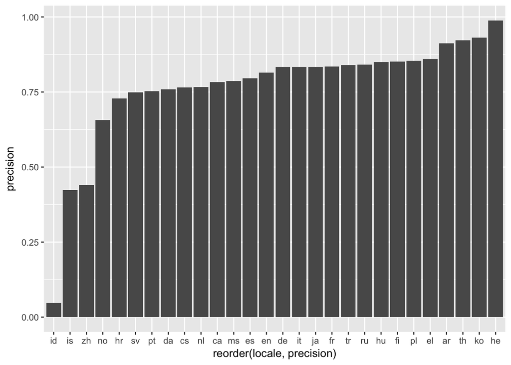

```r
valid_data %>%
  mutate(langdetect_locale = ifelse(langdetect_locale == "id", "ms", langdetect_locale)) %>%
  mutate(mix_locale = ifelse(langdetect_prob >= langdetect_threshold, langdetect_locale, langid_locale)) %>%
  group_by(locale) %>%
  summarise(precision = sum(ifelse(!is.na(mix_locale) & mix_locale == locale, 1, 0)) / n()) %>%
  ggplot(aes(x = reorder(locale, precision), y = precision)) +
    geom_bar(stat="identity")
```

#### Approach-3: Apply different threshold for each language

```r
get_threshold <- function(df, locale_name) {
  precision_df <- data.frame(threshold = numeric(), precision=numeric())
  for (th in seq(0, 1, by=0.01)) {
    p <- (
      df %>%
        filter(locale == locale_name) %>%
        mutate(mix_locale = ifelse(langdetect_prob >= th, langdetect_locale, langid_locale)) %>%
        summarise(precision = sum(ifelse(!is.na(mix_locale) & mix_locale == locale, 1, 0)) / n())
    )$precision

    precision_df[nrow(precision_df) + 1,] = c(th, p)
  }

  max_precision <- (precision_df %>% summarise(max_precision = max(precision)))$max_precision
  max_threshold <- head(precision_df %>% filter(precision == max_precision), 1)$threshold

  max_threshold
}
```

```r
locales <- unique(valid_data$locale)
thresholds <- data.frame(langdetect_locale = character(), threshold = numeric(), stringsAsFactors = FALSE)

for (locale in locales) {
  thresholds[nrow(thresholds) + 1, ] = c(locale, get_threshold(valid_data, locale))
}
```

Let’s evaluate on valid dataset using thresholds

```r
merge(
  valid_data,
  thresholds,
  by = c("langdetect_locale")
) %>%
  mutate(pred_locale = ifelse(!is.na(langdetect_locale) & langdetect_prob >= threshold, langdetect_locale, langid_locale)) %>%
  summarise(precision = sum(ifelse(pred_locale == locale, 1, 0)) / n())
```

| precision |
| --- |
| 0.7909824 |

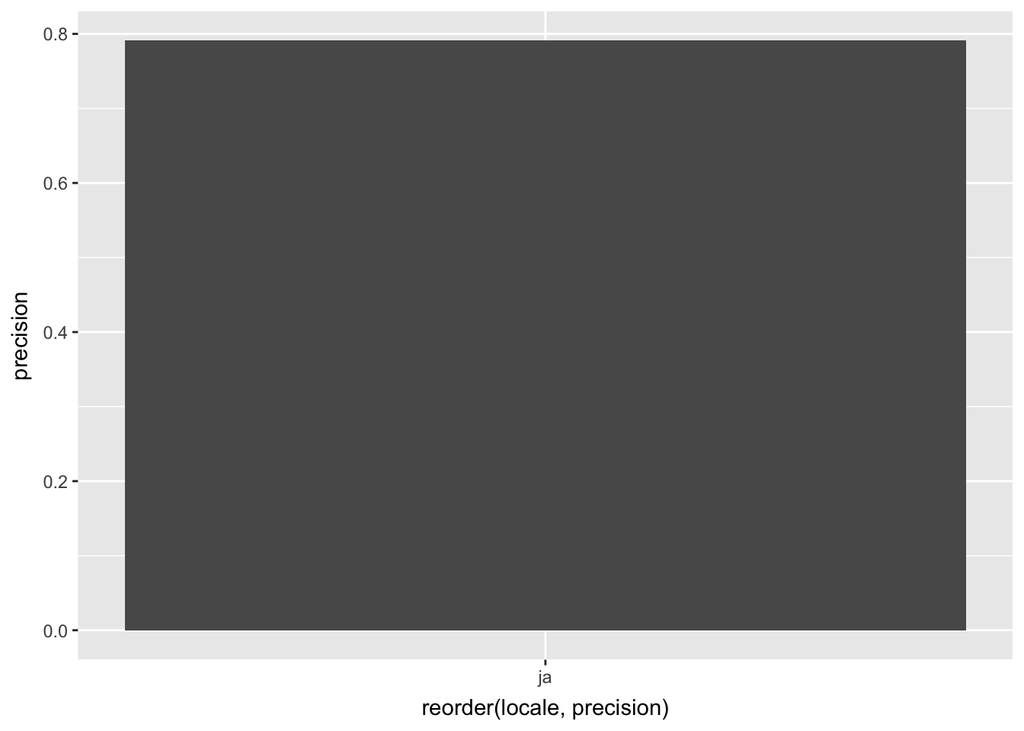

```r
merge(
  valid_data,
  thresholds,
  by = c("langdetect_locale")
) %>%
  mutate(pred_locale = ifelse(!is.na(langdetect_locale) & langdetect_prob >= threshold, langdetect_locale, langid_locale)) %>%
  summarise(precision = sum(ifelse(pred_locale == locale, 1, 0)) / n()) %>%
  ggplot(aes(x = reorder(locale, precision), y = precision)) +
    geom_bar(stat="identity")
```

On evaluation dataset

```r
merge(
  eval_data,
  thresholds,
  by = c("langdetect_locale")
) %>%
  mutate(pred_locale = ifelse(!is.na(langdetect_locale) & langdetect_prob >= threshold, langdetect_locale, langid_locale)) %>%
  summarise(precision = sum(ifelse(pred_locale == locale, 1, 0)) / n())
```

| precision |
| --- |
| 0.786224 |

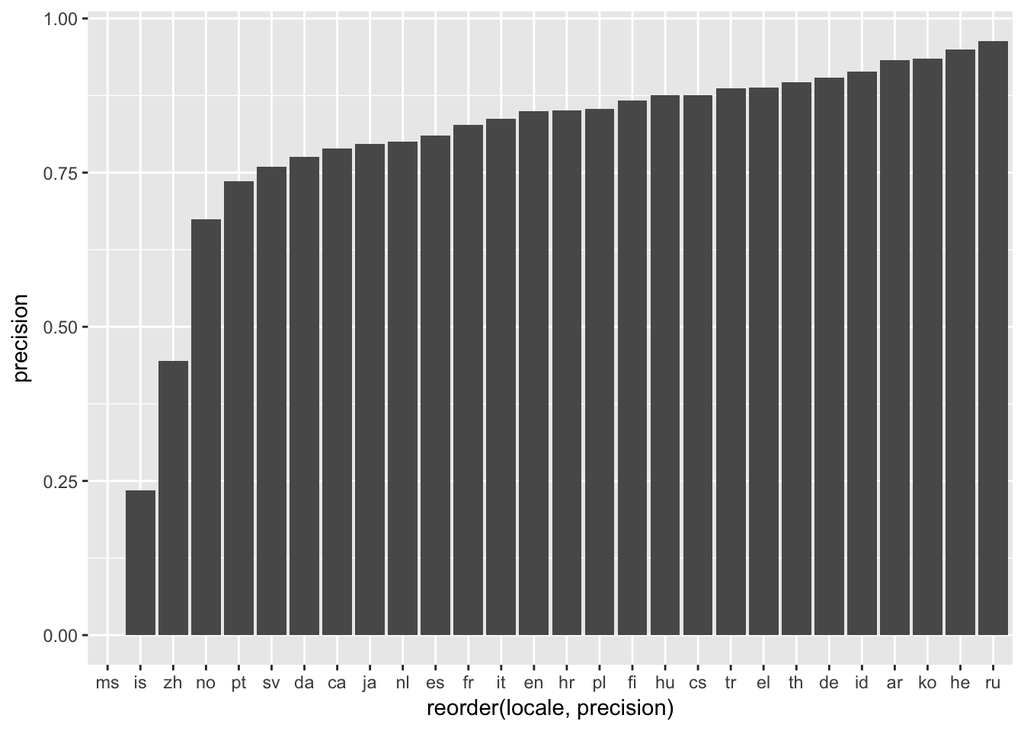

```r
merge(
  eval_data,
  thresholds,
  by = c("langdetect_locale")
) %>%
  mutate(pred_locale = ifelse(!is.na(langdetect_locale) & langdetect_prob >= threshold, langdetect_locale, langid_locale)) %>%
  group_by(locale) %>%
  summarise(precision = sum(ifelse(pred_locale == locale, 1, 0)) / n()) %>%
  ggplot(aes(x = reorder(locale, precision), y = precision)) +
    geom_bar(stat="identity")
```

#### Approach-4: Take whichever with highest confidence

Evaluation of chosen method is:

```r
eval_data %>%
  mutate(mix_locale = ifelse(langdetect_prob >= langid_prob, langdetect_locale, langid_locale)) %>%
  summarise(precision = sum(ifelse(!is.na(mix_locale) & mix_locale == locale, 1, 0)) / n())
```

| precision |
| --- |
| 0.6440888 |

#### Debug

```r
debug_sample <- head(
  valid_data %>%
    filter(locale == "no") %>%
    mutate(mix_locale = ifelse(langdetect_prob >= langdetect_threshold, langdetect_locale, langid_locale)) %>%
    mutate(id = Unnamed..0.1) %>%
    filter(mix_locale != locale) %>%
    select(id, curated_value, locale, mix_locale, langdetect_locale, langdetect_prob, langid_locale, langid_prob),
  100
)
```